# Lab 08 - Predicting rain

Helen Miller

2024-11-15

```r
weather <- read.csv("data/weatherAUS.csv", header = TRUE)
```

# Exercise 1: Exploratory Data Analysis

We will start by transform any character variables that need to be transformed into categorical. Use the following code to identify them and trasform them into factors.

```r
variables_to_transform = weather %>%
  select(where(is.character),-Date) %>% names()
weather <- weather %>%
  mutate_at(vars(all_of(variables_to_transform)),factor)
```

To simplify things, today we will not be using some categorical explanatory variables, because they have a very large number of categories and might make our model interpretation more complex. Specifically we will exclude `WindGustDir`, `WindDir9am` and `WindDir3pm`.

```r
weather <- weather %>%
  select(-WindGustDir,-WindDir9am,-WindDir3pm)
```

Note that some of these variables have a large number of missing values:

```r
weather %>%
  select(where(~ any(is.na(.)))) %>%
  summarise(across(everything(), ~mean(is.na(.)))) %>%
  pivot_longer(col = everything(), names_to = "Variable", values_to = "Prop_NA") %>%
  arrange(desc(Prop_NA))
```

```
## # A tibble: 18 × 2
##    Variable      Prop_NA
##    <chr>           <dbl>
##  1 Sunshine      0.480
##  2 Evaporation   0.432
##  3 Cloud3pm      0.408
##  4 Cloud9am      0.384
##  5 Pressure9am   0.104
##  6 Pressure3pm   0.103
##  7 WindGustSpeed 0.0706
##  8 Humidity3pm   0.0310
##  9 Temp3pm       0.0248
## 10 RainTomorrow  0.0225
## 11 Rainfall      0.0224
## 12 RainToday     0.0224
## 13 WindSpeed3pm  0.0211
## 14 Humidity9am   0.0182
## 15 WindSpeed9am  0.0121
## 16 Temp9am       0.0121
## 17 MinTemp       0.0102
## 18 MaxTemp       0.00867
```

1. Are there any missing values in our variable of interest `RainTomorrow`? If so, we filter them out and save the new dataset as `weather_noNA`.

```r
weather_noNA <- weather %>%
  filter(!is.na(RainTomorrow))
glimpse(weather_noNA)
```

```
## Rows: 142,193
## Columns: 20
## $ Date          <chr> "2008-12-01", "2008-12-02", "2008-12-03", "2008-12-04", …
## $ Location      <fct> Albury, Albury, Albury, Albury, Albury, Albury, Albury, …
## $ MinTemp       <dbl> 13.4, 7.4, 12.9, 9.2, 17.5, 14.6, 14.3, 7.7, 9.7, 13.1, …
## $ MaxTemp       <dbl> 22.9, 25.1, 25.7, 28.0, 32.3, 29.7, 25.0, 26.7, 31.9, 30…
## $ Rainfall      <dbl> 0.6, 0.0, 0.0, 0.0, 1.0, 0.2, 0.0, 0.0, 0.0, 1.4, 0.0, 2…
## $ Evaporation   <dbl> NA, NA, NA, NA, NA, NA, NA, NA, NA, NA, NA, NA, NA, NA, …
## $ Sunshine      <dbl> NA, NA, NA, NA, NA, NA, NA, NA, NA, NA, NA, NA, NA, NA, …
## $ WindGustSpeed <int> 44, 44, 46, 24, 41, 56, 50, 35, 80, 28, 30, 31, 61, 44, …
## $ WindSpeed9am  <int> 20, 4, 19, 11, 7, 19, 20, 6, 7, 15, 17, 15, 28, 24, NA, …
## $ WindSpeed3pm  <int> 24, 22, 26, 9, 20, 24, 24, 17, 28, 11, 6, 13, 28, 20, 22…
## $ Humidity9am   <int> 71, 44, 38, 45, 82, 55, 49, 48, 42, 58, 48, 89, 76, 65, …
## $ Humidity3pm   <int> 22, 25, 30, 16, 33, 23, 19, 19, 9, 27, 22, 91, 93, 43, 2…
## $ Pressure9am   <dbl> 1007.7, 1010.6, 1007.6, 1017.6, 1010.8, 1009.2, 1009.6, …
## $ Pressure3pm   <dbl> 1007.1, 1007.8, 1008.7, 1012.8, 1006.0, 1005.4, 1008.2, …
## $ Cloud9am      <int> 8, NA, NA, NA, 7, NA, 1, NA, NA, NA, NA, 8, 8, NA, 0, 8,…
## $ Cloud3pm      <int> NA, NA, 2, NA, 8, NA, NA, NA, NA, NA, NA, 8, 8, 7, NA, 1…
## $ Temp9am       <dbl> 16.9, 17.2, 21.0, 18.1, 17.8, 20.6, 18.1, 16.3, 18.3, 20…
## $ Temp3pm       <dbl> 21.8, 24.3, 23.2, 26.5, 29.7, 28.9, 24.6, 25.5, 30.2, 28…
## $ RainToday     <fct> No, No, No, No, No, No, No, No, No, Yes, No, Yes, Yes, Y…
## $ RainTomorrow  <fct> No, No, No, No, No, No, No, No, Yes, No, Yes, Yes, Yes, …
```

2. Which cities are the ones with more rain days? To do this, let’s analyze the `RainToday` variable.

```r
weather_noNA %>%
  filter(RainToday == 'Yes') %>%
  group_by(Location) %>%
  summarise(rain_count = n()) %>%
  arrange(desc(rain_count))
```

```
## # A tibble: 49 × 2
##    Location      rain_count
##    <fct>              <int>
##  1 Portland            1088
##  2 Cairns               941
##  3 Walpole              928
##  4 Dartmoor             921
##  5 MountGambier         919
##  6 NorfolkIsland        912
##  7 Albany               893
##  8 Witchcliffe          871
##  9 Sydney               866
## 10 CoffsHarbour         865
## # ℹ 39 more rows
```

# Exercise 2: Logistic regression

We will focus our analysis on the city of `Portland`. Remove `eval=FALSE` from below once you have defined the object `weather_noNA`.

```r
# remove eval=FALSE
weather_noNA$RainTomorrow <- factor(weather_noNA$RainTomorrow, levels = c("No", "Yes"))
glimpse(weather_noNA)
```

```
## Rows: 142,193
## Columns: 20
## $ Date          <chr> "2008-12-01", "2008-12-02", "2008-12-03", "2008-12-04", …
## $ Location      <fct> Albury, Albury, Albury, Albury, Albury, Albury, Albury, …
## $ MinTemp       <dbl> 13.4, 7.4, 12.9, 9.2, 17.5, 14.6, 14.3, 7.7, 9.7, 13.1, …
## $ MaxTemp       <dbl> 22.9, 25.1, 25.7, 28.0, 32.3, 29.7, 25.0, 26.7, 31.9, 30…
## $ Rainfall      <dbl> 0.6, 0.0, 0.0, 0.0, 1.0, 0.2, 0.0, 0.0, 0.0, 1.4, 0.0, 2…
## $ Evaporation   <dbl> NA, NA, NA, NA, NA, NA, NA, NA, NA, NA, NA, NA, NA, NA, …
## $ Sunshine      <dbl> NA, NA, NA, NA, NA, NA, NA, NA, NA, NA, NA, NA, NA, NA, …
## $ WindGustSpeed <int> 44, 44, 46, 24, 41, 56, 50, 35, 80, 28, 30, 31, 61, 44, …
## $ WindSpeed9am  <int> 20, 4, 19, 11, 7, 19, 20, 6, 7, 15, 17, 15, 28, 24, NA, …
## $ WindSpeed3pm  <int> 24, 22, 26, 9, 20, 24, 24, 17, 28, 11, 6, 13, 28, 20, 22…
## $ Humidity9am   <int> 71, 44, 38, 45, 82, 55, 49, 48, 42, 58, 48, 89, 76, 65, …
## $ Humidity3pm   <int> 22, 25, 30, 16, 33, 23, 19, 19, 9, 27, 22, 91, 93, 43, 2…
## $ Pressure9am   <dbl> 1007.7, 1010.6, 1007.6, 1017.6, 1010.8, 1009.2, 1009.6, …
## $ Pressure3pm   <dbl> 1007.1, 1007.8, 1008.7, 1012.8, 1006.0, 1005.4, 1008.2, …
## $ Cloud9am      <int> 8, NA, NA, NA, 7, NA, 1, NA, NA, NA, NA, 8, 8, NA, 0, 8,…
## $ Cloud3pm      <int> NA, NA, 2, NA, 8, NA, NA, NA, NA, NA, NA, 8, 8, 7, NA, 1…
## $ Temp9am       <dbl> 16.9, 17.2, 21.0, 18.1, 17.8, 20.6, 18.1, 16.3, 18.3, 20…
## $ Temp3pm       <dbl> 21.8, 24.3, 23.2, 26.5, 29.7, 28.9, 24.6, 25.5, 30.2, 28…
## $ RainToday     <fct> No, No, No, No, No, No, No, No, No, Yes, No, Yes, Yes, Y…
## $ RainTomorrow  <fct> No, No, No, No, No, No, No, No, Yes, No, Yes, Yes, Yes, …
```

```r
weather_Portland <- weather_noNA %>%
 filter(Location == "Portland")
```

1. Try to predict `RainTomorrow` by fitting a linear regression using the variable `RainToday` and print the output using `tidy()`.

```r
unique(weather_Portland$RainTomorrow)
```

```
## [1] Yes No
## Levels: No Yes
```

```r
model_port <- logistic_reg() %>%
  set_engine("glm") %>%
  fit(RainTomorrow ~ RainToday, data = weather_Portland, family = "binomial")
tidy(model_port)
```

```
## # A tibble: 2 × 5
##   term         estimate std.error statistic  p.value
##   <chr>           <dbl>     <dbl>     <dbl>    <dbl>
## 1 (Intercept)     -1.08    0.0527     -20.4 1.51e-92
## 2 RainTodayYes     1.33    0.0807      16.5 4.39e-61
```

2. For each point in our dataset, what are the fitted probabilities that tomorrow it’s going to rain?
- Plot them using an appropriate visualization. What is peculiar about them?

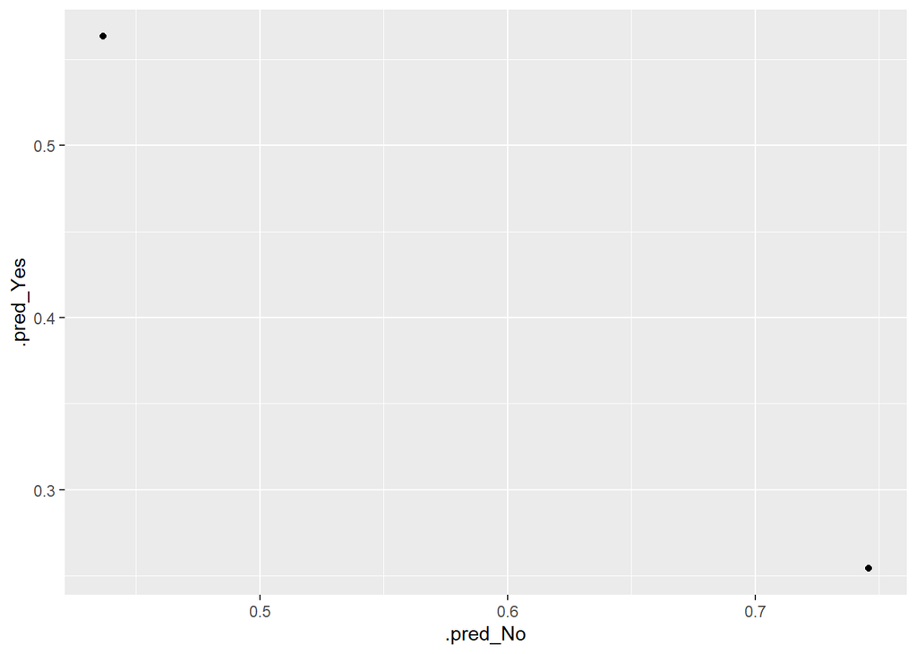

```r
model_pred <- predict(model_port, weather_Portland, type = "prob") %>%
  bind_cols(weather_Portland)

ggplot(mapping = aes(x=.pred_No, y=.pred_Yes), data = model_pred) +
  geom_point()
```

> Hint: how many unique values do the predicted probabilities take? What do these value correspond to?

*The prodicted probablilities only take two values*

- Are there any missing values? Why?

```r
colSums(is.na(model_pred))
```

```
##      .pred_No     .pred_Yes          Date      Location       MinTemp
##            12            12             0             0             9
##       MaxTemp      Rainfall   Evaporation      Sunshine WindGustSpeed
##             1            12           407           441            24
##  WindSpeed9am  WindSpeed3pm   Humidity9am   Humidity3pm   Pressure9am
##             2             2            49            13            12
##   Pressure3pm      Cloud9am      Cloud3pm       Temp9am       Temp3pm
##            10           409           518            48            12
##     RainToday  RainTomorrow
##            12             0
```

*These will be values where RainToday was NA.*

# Exercise 3: Split the data and build workflows

Let us set a seed and perform a split of our data.

```r
set.seed(111723)
```

1. Split the data into a training set (80% of your Portland data) and a testing set.

```r
port_split <- initial_split(weather_Portland, prop = 0.80)
# Create data frames for the two sets:
train_data <- training(port_split)
test_data  <- testing(port_split)
```

2. Refit the simple logistic regression using `RainToday` as predictor on this training data, using `tidymodels` recipes and workflows.
- Start by the recipe. First initialize the recipe, then remove observations with missing values using `step_naomit()` and finally use `step_dummy` to convert categorical to dummy variables.

```r
# remove eval=FALSE
weather_rec1 <- recipe(
  RainTomorrow ~ RainToday,
  data = weather_Portland
  ) %>%
  step_naomit(all_predictors()) %>%
  step_dummy(all_nominal(), -all_outcomes())
```

- Build your workflow combining model and recipe

```r
# remove eval=FALSE
weather_mod1 <- logistic_reg() %>%
  set_engine('glm')
weather_wflow1 <- workflow() %>% # initiate workflow
  add_model(weather_mod1) %>%                   # add model
  add_recipe(weather_rec1)                       # add recipe
```

```r
# remove eval=FALSE
weather_fit1 <- weather_wflow1 %>%
  fit(data = weather_Portland)
tidy(weather_fit1)
```

```
## # A tibble: 2 × 5
##   term          estimate std.error statistic  p.value
##   <chr>            <dbl>     <dbl>     <dbl>    <dbl>
## 1 (Intercept)      -1.08    0.0527     -20.4 1.51e-92
## 2 RainToday_Yes     1.33    0.0807      16.5 4.39e-61
```

3. Fit now a multiple logistic regression, i.e. using multiple explanatory variables, to predict `RainTomorrow`. We will use as predictors the variables `MinTemp`, `MaxTemp`, `RainToday` and `Rainfall`. Similarly to question 2, use workflows to fit this model on our training data.
- Start by the recipe. This will be a simple recipe, because we have not done many pre-processing steps, but do remove missing values and transform categorical variables into dummy variables:

```r
# remove eval=FALSE
weather_rec2 <- recipe(
  RainTomorrow ~ MinTemp + MaxTemp + RainToday + Rainfall, # include your formula
  data = weather_Portland
  ) %>%
  step_naomit(all_predictors()) %>%
  step_dummy(all_nominal(), -all_outcomes())
```

```r
weather_wflow2 <- workflow() %>%
  add_recipe(weather_rec2) %>%
  add_model(weather_mod1)

weather_fit2 <- weather_wflow2 %>%
  fit(data = weather_Portland)
tidy(weather_fit2)
```

```
## # A tibble: 5 × 5
##   term          estimate std.error statistic  p.value
##   <chr>            <dbl>     <dbl>     <dbl>    <dbl>
## 1 (Intercept)     0.406     0.196      2.07  3.82e- 2
## 2 MinTemp         0.0101    0.0141     0.716 4.74e- 1
## 3 MaxTemp        -0.0831    0.0123    -6.77  1.26e-11
## 4 Rainfall        0.0502    0.0108     4.66  3.13e- 6
## 5 RainToday_Yes   0.700     0.109      6.41  1.44e-10
```

```r
# remove eval=FALSE
weather_pred2 <- predict(weather_fit2, test_data, type = "prob") %>%
  bind_cols(test_data)
```

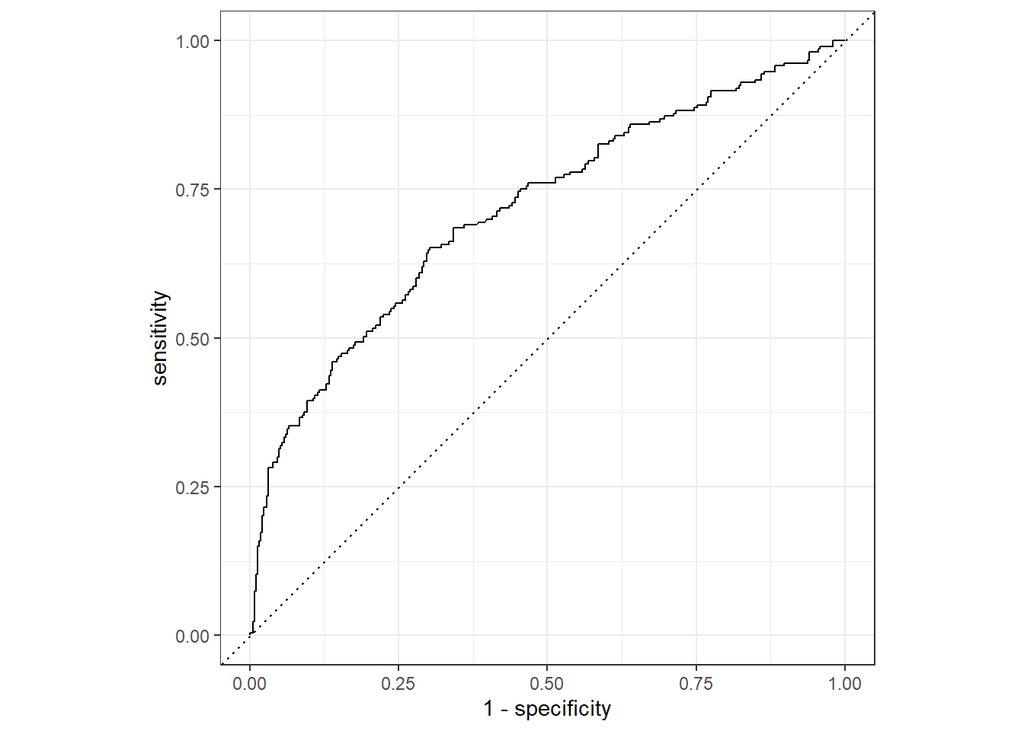

```r
weather_pred2 %>%
  roc_curve(                      # plot ROC curve
    truth = RainTomorrow,
    .pred_Yes,
    event_level = "second"
  ) %>%
  autoplot()
```

```r
weather_pred2 %>%
  roc_auc(                  # get AUC value
    truth = RainTomorrow,
    .pred_Yes,
    event_level = "second"
  )
```

```
## # A tibble: 1 × 3
##   .metric .estimator .estimate
##   <chr>   <chr>          <dbl>
## 1 roc_auc binary         0.715
```

```r
weather_pred1 <- predict(weather_fit1, test_data, type = "prob") %>%
  bind_cols(test_data)
```

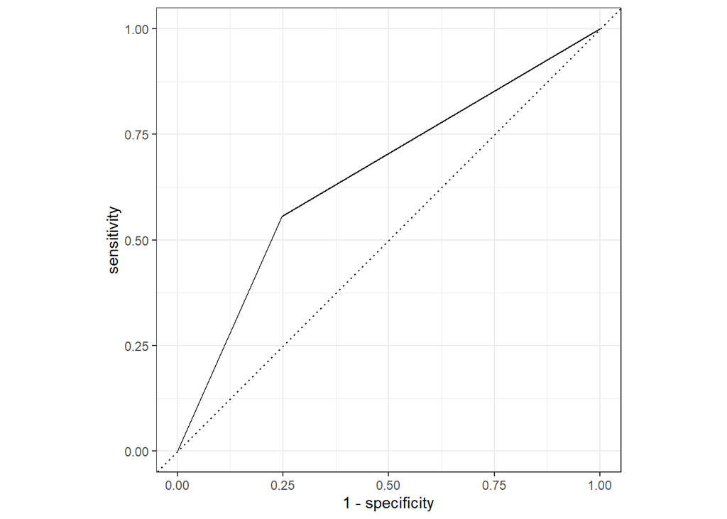

```r
weather_pred1 %>%
  roc_curve(                      # plot ROC curve
    truth = RainTomorrow,
    .pred_Yes,
    event_level = "second"
  ) %>%
  autoplot()
```

```r
weather_pred1 %>%
  roc_auc(                  # get AUC value
    truth = RainTomorrow,
    .pred_Yes,
    event_level = "second"
  )
```

```
## # A tibble: 1 × 3
##   .metric .estimator .estimate
##   <chr>   <chr>          <dbl>
## 1 roc_auc binary         0.654
```

- Which model seems to have a better performance?

*The second one*

4. Now focus on the second model. Consider several thresholds for predicting `RainTomorrow` and look at the number of false positives and false negatives. For example:

```r
# remove eval = FALSE
cutoff_prob <- 0.3
weather_pred2 %>%
  mutate(
    RainTomorrow      = if_else(RainTomorrow == "Yes", "It rains", "It does not rain"),
    RainTomorrow_pred = if_else(.pred_Yes > cutoff_prob, "Predicted rain", "Predicted no rain")
    ) %>%
  na.omit() %>%
  count(RainTomorrow_pred, RainTomorrow)
```

```
## # A tibble: 4 × 3
##   RainTomorrow_pred RainTomorrow         n
##   <chr>             <chr>            <int>
## 1 Predicted no rain It does not rain   122
## 2 Predicted no rain It rains            32
## 3 Predicted rain    It does not rain   106
## 4 Predicted rain    It rains           106
```

- What is the the false positive rate with `cutoff_prob = 0.3`?

- What about the false negative rate?

# Exercise 4: Extend our model [OPTIONAL]

We will now try to improve our fit by building a model using additional explanatory variables.

1. Let us analyze the various variables in our dataset.
- Is there any categorical variable which is very unbalanced? If so, remove it.
- Is there any numerical variable that has a very small standard deviation for one of the two categories of `RainTomorrow`? If so, remove it.
2. Let’s do some feature engineering: let us transform the variable `Date`. We will use `Ludbridate` again: extract the month and year.
3. Let’s now combine everything into recipes and workflows. Then fit the model on the training data and use the test data for calculating the AUC and plotting the ROC curve.
4. Is this model better than the one we fitted in Exercise 3?